# Taller 3 de Machine Learning Avanzado

Diabb Zegpi Delgado

```r
# Dependencias
# install.packages(c("tidyverse", "tidymodels","here", "janitor", reticulate", "keras"))

library(tidyverse)
library(tidymodels)
library(here)
startup_raw <- read_csv(file = here("Machine Learning Avanzado", "startup data.csv")) %>%
  janitor::clean_names()
```

El dataset `startup` registra información de empresas emergentes (startups) en Estados Unidos. En total, contiene 923 filas y 49 columnas. Cada fila representa a una startup y cada columna a una característica de ésta. Inicialmente, hay muchas columnas que pueden ser construidas a partir de éstas, causando así duplicidad de datos. Por tanto, el primer análisis consistirá en determinar cuáles columnas pueden ser excluidas del dataset sin perder información relevante.

Las variables dummy a descartar serán reconstruidas en el proceso de modelamiento, pero, por el momento, serán excluidas.

```r
startup <- startup_raw %>%
  select(-c(unnamed_0, zip_code, id, unnamed_6, labels, closed_at, state_code_1, object_id),
         -starts_with("is_"))

colnames(startup)
```

```
##  [1] "state_code"               "latitude"
##  [3] "longitude"                "city"
##  [5] "name"                     "founded_at"
##  [7] "first_funding_at"         "last_funding_at"
##  [9] "age_first_funding_year"   "age_last_funding_year"
## [11] "age_first_milestone_year" "age_last_milestone_year"
## [13] "relationships"            "funding_rounds"
## [15] "funding_total_usd"        "milestones"
## [17] "category_code"            "has_vc"
## [19] "has_angel"                "has_round_a"
## [21] "has_round_b"              "has_round_c"
## [23] "has_round_d"              "avg_participants"
## [25] "status"
```

```r
startup <- startup %>%
  mutate(across(
    matches("fo?und") & where(is.character),
    function(x) as.Date(x, format = "%m/%d/%Y")
  ))
```

### Variables fecha

- Las empresas fueron fundadas entre el 1 de enero de 1984 y el 16 de abril de 2013.
- Todas las empresas obtuvieron su primer financiamiento entre enero del 2000 y noviembre del 2013.
- Todas las empresas obtuvieron su último financiamiento entre enero del 2001 y noviembre del 2013.

### Variables numéricas

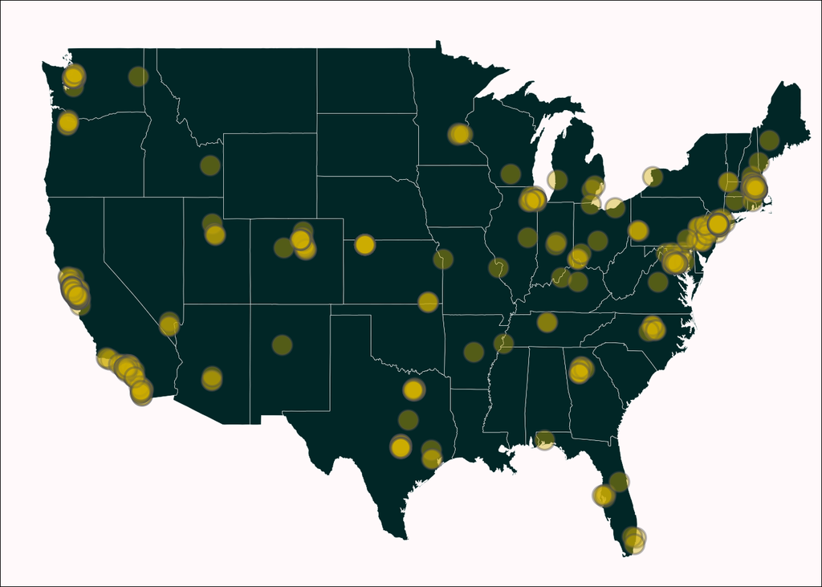

El mapa superior muestra las empresas registradas en USA. Solamente hay 4 empresas fuera de USA: Xelerated en el Mar Arábigo (Sureste de Omán), Moli, DiJiPOP y Tracelytics, las tres en el Océano Índico, al Este de Somalia. Por supuesto, las cuatro empresas se encuentran adscritas a ciudades estadounidenses, por lo que sus coordenadas son susceptibles a imputación. Las demás variables numéricas se describen a continuación:

- Los rangos de las variables de antigüedad de las empresas hasta su primer o último financiamiento e hito incluyen números negativos. Esto se interpreta como factible.
- La antigüedad de las empresas hasta su primer y último hito tiene missing data. Se detecta dependencia entre estas variables y el *status* de las empresas.
- Las correlaciones entre las variables numéricas se muestran en la matriz de correlación.

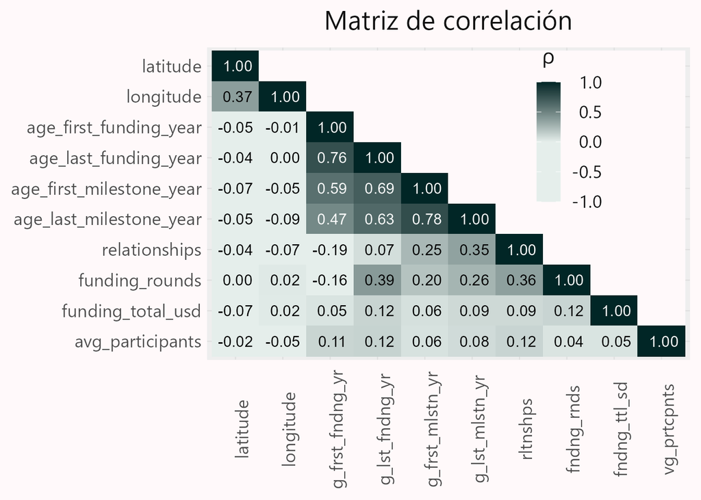

Se observa correlación moderada-alta entre la antigüedad de la startup en su primer y último financiamiento. Esta correlación indica que el tiempo que transcurre entre ambos eventos varía en forma lineal de empresa en empresa. A su vez, las variables mencionadas se correlacionan moderadamente con la antigüedad de la empresa en su primer/último hito.

Se estima que no hay correlaciones suficientemente altas entre los predictores, por ende, no se elimina ninguno del dataset. A continuación, se imputan los valores de latitud y longitud de las empresas ubicadas en el Mar Arábigo, con la media de sus vecinos más cercanos, utilizando las columnas `state_code`, `city` y `category_code`.

Respecto a las columnas `age_first_milestone_year` y `age_last_milestone_year`, ambas tienen 152 valores faltantes, en los mismos registros. Además, esto se condice con la columna `milestones`: la startup no registra milestones si y solo si adolesce de valores faltantes. Por simplicidad, las dos columnas `age_` serán excluidas del dataset.

```r
outliers <- startup %>%
  slice_max(latitude, n = 4) %>%
  pull(name)

startup_to_impute <- startup %>%
  mutate(latitude = if_else(name %in% outliers, NA_real_, latitude),
         longitude = if_else(name %in% outliers, NA_real_, longitude))


impute_recipe <- recipe(~ ., data = startup_to_impute) %>%
  update_role(name, new_role = "id") %>%
  step_other(state_code, threshold = 10) %>%
  step_other(city, threshold = 10) %>%
  step_other(category_code, threshold = 10, other = "Other") %>%
  step_impute_knn(longitude, impute_with = c("state_code", "city", "category_code")) %>%
  step_impute_knn(latitude, impute_with = c("state_code", "city", "category_code"))

imputed_values <- impute_recipe %>%
  prep() %>%
  bake(new_data = NULL) %>%
  filter(name %in% outliers) %>%
  select(lat = latitude, long = longitude, name)

startup_imputed <- startup_to_impute %>%
  left_join(imputed_values, by = "name") %>%
  mutate(latitude = if_else(is.na(latitude), lat, latitude),
         longitude = if_else(is.na(longitude), long, longitude)) %>%
  select(-c(lat, long, age_first_milestone_year, age_last_milestone_year)) %>%
  mutate(status = factor(status),
         id = row_number())
```

Finalmente, se particionan los datos en conjuntos de entrenamiento y prueba. A partir del conjunto de entrenamiento, se generan 10 conjuntos de validación utilizando* bootstrapping* estratificado.

```r
set.seed(123)
startup_split <- initial_split(startup_imputed, strata = status)
startup_train <- training(startup_split)
startup_test <- testing(startup_split)

set.seed(123)
startup_boots <- bootstraps(startup_train, times = 10, strata = status)
```

## Preprocesamiento de datos

Previo al entrenamiento de modelos con bootstrapping, se procede a realizar varias transformaciones sobre los datos:

- Se declara que el rol de las variables `name` y `id` es meramente identificador, es decir, no serán usadas para ajustar los modelos.
- Se agrupan las categorías con menos de 10 observaciones, de las variables `state_code`, `city` y `category_code`.
- Se crean variables dummy a partir de las categorías.
- Se extrae el año de las fechas.
- Se realiza una transformación logarítmica sobre las variables `funding_total_usd` y `avg_participants`, porque sus distribuciones son de gran varianza y sesgo.
- Se normalizan ($\mu=0$ y $\sigma=1$) los predictores numéricos.
- Se muestrea con reemplazo el nivel minoritario (closed) de la variable respuesta, hasta alcanzar un ratio de 1 entre las categorías.

```r
library(themis)

preprocessing <- recipe(status ~ ., data = startup_train) %>%
  update_role(name, id, new_role = "id") %>%
  step_other(state_code, threshold = 10) %>%
  step_other(city, threshold = 10) %>%
  step_other(category_code, threshold = 10, other = "Other") %>%
  step_dummy(all_nominal_predictors()) %>%
  step_date(founded_at, first_funding_at, last_funding_at,
            features = "year", keep_original_cols = FALSE) %>%
  step_log(funding_total_usd, avg_participants) %>%
  step_normalize(all_numeric_predictors()) %>%
  step_upsample(status)
```

## Entrenamiento de red neuronal 1

Lo primero es crear una especificación de modelo de red neuronal MLP (multilayer perceptron), en este caso, de una sola capa. El hiperparámetro a optimizar es la cantidad de perceptrones en la capa oculta, denotado por el argumento `hidden_units = tune()`. Esta configuración, por defecto, especifica que se entrenará la red con una grilla de 10 valores, entre 1 y 10, para la cantidad de unidades ocultas. La función de activación por defecto para problemas de clasificación es *softmax*.

```r
neural_net_1 <- mlp(hidden_units = tune()) %>%
  set_mode("classification") %>%
  set_engine("nnet")
neural_net_1
```

```
## Single Layer Neural Network Specification (classification)
##
## Main Arguments:
##   hidden_units = tune()
##
## Computational engine: nnet
```

Luego, se incorporan tanto la especificación del modelo como las instrucciones de preprocesamiento en un objeto *workflow*.

```r
nnet_wf <- workflow() %>%
  add_recipe(preprocessing) %>%
  add_model(neural_net_1)
nnet_wf
```

```
## == Workflow ====================================================================
## Preprocessor: Recipe
## Model: mlp()
##
## -- Preprocessor ----------------------------------------------------------------
## 8 Recipe Steps
##
## * step_other()
## * step_other()
## * step_other()
## * step_dummy()
## * step_date()
## * step_log()
## * step_normalize()
## * step_upsample()
##
## -- Model -----------------------------------------------------------------------
## Single Layer Neural Network Specification (classification)
##
## Main Arguments:
##   hidden_units = tune()
##
## Computational engine: nnet
```

```r
library(doParallel)
ncores <- detectCores() - 1
cl <- makePSOCKcluster(ncores)
registerDoParallel(cl)

nnet_grid_1 <- grid_regular(hidden_units(), levels = 10)

set.seed(123)
nnet_results_1 <- tune_grid(
  nnet_wf,
  resamples = startup_boots,
  grid = nnet_grid_1,
  control = control_grid(save_pred = TRUE, allow_par = TRUE)
)

stopImplicitCluster()
```

## Entrenamiento de SVM

Para el modelo de SVM se utiliza el mismo preprocesador que para la red neuronal.

```r
svm_spec <- svm_rbf() %>%
  set_mode("classification") %>%
  set_engine("kernlab")


svm_wf <- workflow() %>%
  add_recipe(preprocessing) %>%
  add_model(svm_spec)
svm_wf
```

```
## == Workflow ====================================================================
## Preprocessor: Recipe
## Model: svm_rbf()
##
## -- Preprocessor ----------------------------------------------------------------
## 8 Recipe Steps
##
## * step_other()
## * step_other()
## * step_other()
## * step_dummy()
## * step_date()
## * step_log()
## * step_normalize()
## * step_upsample()
##
## -- Model -----------------------------------------------------------------------
## Radial Basis Function Support Vector Machine Specification (classification)
##
## Computational engine: kernlab
```

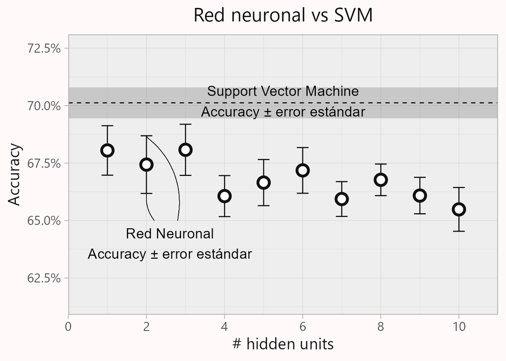

```r
registerDoParallel(cl)

svm_results <- fit_resamples(
  svm_wf,
  resamples = startup_boots,
  control = control_resamples(save_pred = TRUE, allow_par = TRUE)
)

stopImplicitCluster()
```

```r
svm_results %>%
  collect_predictions() %>%
  count(id, .pred_class, status) %>%
  group_by(.pred_class, status) %>%
  summarize(pred_class = mean(n), .groups = "drop") %>%
  pivot_wider(names_from = status, values_from = pred_class)
```

```
## # A tibble: 2 x 3
##   .pred_class acquired closed
##   <fct>          <dbl>  <dbl>
## 1 acquired       128.    37.5
## 2 closed          38.5   50.2
```

## Entrenamiento de red neuronal 2

El entrenamiento de la red neuronal profunda será llevado a cabo utilizando el paquete `keras`. Este framework necesita que los datos de entrenamiento y prueba ingresen al modelo en forma matricial.

```r
library(keras)

x_train <- preprocessing %>%
  prep() %>%
  juice(all_predictors(), composition = "matrix")

y_train <- preprocessing %>%
  prep() %>%
  juice(all_outcomes()) %>%
  pull() %>%
  as.numeric() %>%
  {. - 1} %>%
  to_categorical(num_classes = 2)

x_test <- preprocessing %>%
  prep() %>%
  bake(new_data = startup_test, all_predictors(), composition = "matrix")

y_test <- preprocessing %>%
  prep() %>%
  bake(new_data = startup_test, all_outcomes()) %>%
  pull() %>%
  as.numeric() %>%
  {. - 1} %>%
  to_categorical(num_classes = 2)
```

La afinación de hiperparámetros la realiza la función `tuning_run()` del paquete `tfruns`. Esta función llama a un archivo de extensión `.R` que contiene al modelo, para variar sus parámetros y entrenar los modelos de manera iterativa. El script `keras_model.R` se muestra a continuación.

```r
library(keras)

model_flags <- flags(
  flag_integer("layer_1", default = 10),
  flag_integer("layer_2", default = 10),
  flag_integer("layer_3", default = 10),
  flag_integer("layer_4", default = 10),
  flag_integer("layer_5", default = 10)
)

model_keras <- keras_model_sequential() %>%
  layer_dense(units = model_flags$layer_1, activation = "relu", input_shape = 59) %>%
  layer_dropout(rate = .4) %>%
  layer_dense(units = model_flags$layer_2, activation = "relu") %>%
  layer_dropout(rate = .3) %>%
  layer_dense(units = model_flags$layer_3, activation = "relu") %>%
  layer_dropout(rate = .2) %>%
  layer_dense(units = model_flags$layer_4, activation = "relu") %>%
  layer_dropout(rate = .1) %>%
  layer_dense(units = model_flags$layer_5, activation = "relu") %>%
  layer_dense(units = 2, activation = "softmax")

model_keras %>% compile(
  optimizer = optimizer_rmsprop(learning_rate = .001),
  loss = "categorical_crossentropy",
  metrics = c("accuracy")
)

history <- model_keras %>% fit(
  x_train, y_train,
  epochs = 20,
  batch_size = 128,
  validation_split = .2
)

plot(history)

score <- model_keras %>% evaluate(
  x_test, y_test,
  verbose = 0
)
```

Solamente se entrena a una muestra del 1% de los modelos de 5 capas ocultas, de un total de 32800 arquitecturas. Esta celda de código es costosa de ejecutar, y se recomienda guardar los resultados una vez corrido el código, o descargar el archivo del [repositorio en github](https://github.com/DiabbZegpi/Data-Science-USS/tree/master/Machine%20Learning%20Avanzado).

```r
# Optimización de hiperparámetros
tune_pars <- list(
  layer_1 = c(10, seq(20, 140, by = 20)),
  layer_2 = c(10, seq(20, 140, by = 20)),
  layer_3 = c(10, seq(20, 140, by = 20)),
  layer_4 = c(10, seq(20, 140, by = 20)),
  layer_5 = c(10, seq(20, 140, by = 20))
)

library(tfruns)

runs <- tuning_run(file = here("Machine Learning Avanzado", "keras_model.R"),
                   runs_dir = here("Machine Learning Avanzado", "keras_runs"),
                   flags = tune_pars,
                   sample = .01)
```

## Análisis de los resultados

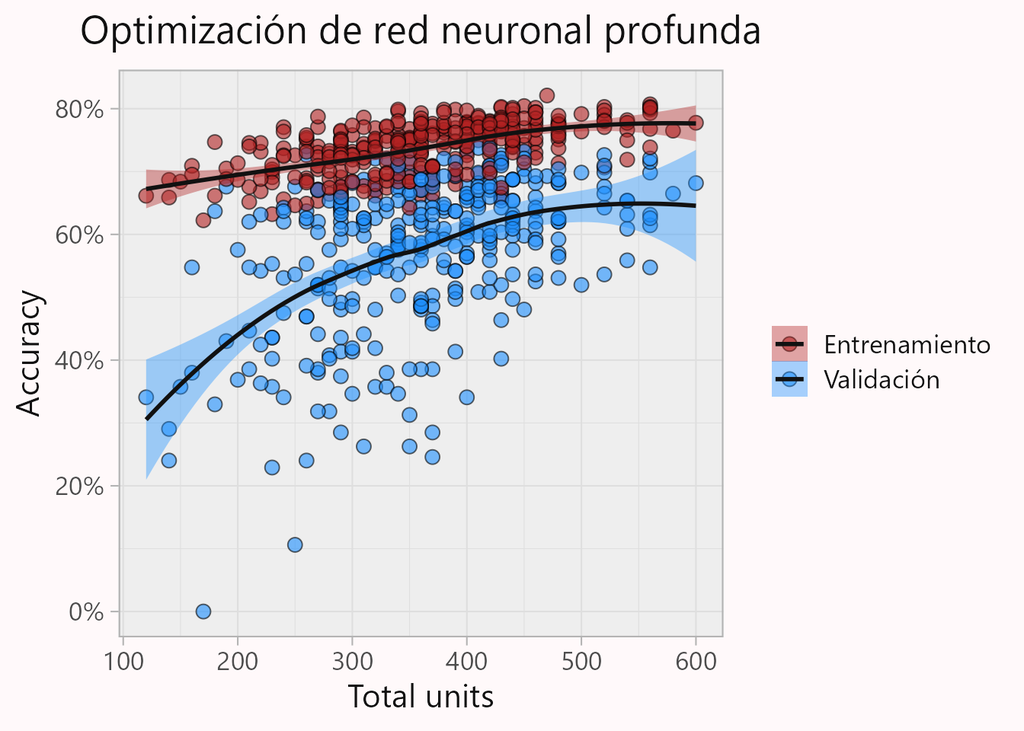

Ahora se reentrena el modelo con la mejor combinación alcanzada.

```r
library(keras)

model_keras <- keras_model_sequential() %>%
  layer_dense(units = 100, activation = "relu", input_shape = 59) %>%
  layer_dropout(rate = .4) %>%
  layer_dense(units = 60, activation = "relu") %>%
  layer_dropout(rate = .3) %>%
  layer_dense(units = 140, activation = "relu") %>%
  layer_dropout(rate = .2) %>%
  layer_dense(units = 10, activation = "relu") %>%
  layer_dropout(rate = .1) %>%
  layer_dense(units = 100, activation = "relu") %>%
  layer_dense(units = 2, activation = "softmax")

model_keras %>% compile(
  optimizer = optimizer_rmsprop(learning_rate = .001),
  loss = "categorical_crossentropy",
  metrics = c("accuracy")
)

model_keras %>% compile(
  optimizer = optimizer_rmsprop(learning_rate = .001),
  loss = "categorical_crossentropy",
  metrics = c("accuracy")
)

history <- model_keras %>% fit(
  x_train, y_train,
  epochs = 20,
  batch_size = 128,
  validation_split = .2
)
```

```r
preds <- model_keras %>%
  predict(x_test) %>%
  as_tibble(.name_repair = function(x) c("acquired", "closed")) %>%
  bind_cols(preprocessing %>%
              prep() %>%
              bake(new_data = startup_test, all_outcomes())) %>%
  mutate(pred = if_else(acquired > closed, "acquired", "closed"),
         pred = factor(pred))

preds %>% accuracy(truth = status, pred)
```

```
## # A tibble: 1 x 3
##   .metric  .estimator .estimate
##   <chr>    <chr>          <dbl>
## 1 accuracy binary         0.754
```

```r
preds %>% conf_mat(truth = status, pred)
```

```
##           Truth
## Prediction acquired closed
##   acquired      126     33
##   closed         24     49
```